# Practical Machine Learning Course Project

Joe White

August 22, 2015

### Executive Summary

This report examines activity data for Human Activity Recognition project [1] and develops a Random Forest model to predict the type of activity being performed based on data captured from wearable devices. The accuracy of the captured model and an estimation of the error inherent in the model is provided below.

### Data Processing and Setup

The first step with the data is to pre process the data and to remove invalid information. In this case there are blanks, NA, and divide by zero errors in the data set. All of those values are replaced with 0 when the data set is read in. This allows the model to accurately predict outcomes using consistently formatted input data. Finally, the row name column is removed.

Then the training data is partitioned into a training and test set. In this case 70% of the data will be used for training and 30% will be used for cross-validation.

```r
inTrain <- createDataPartition(y=activity$classe,p=0.7, list=FALSE)
training <- activity[inTrain,]
testing <- activity[-inTrain,]
```

### Training

The selected model is a Random Forest. Other models were tested including glm and treebag but the results were similar and space considerations prevent reviewing all of the examined models.

The section on Parameter Exploration below examines engineering the parameters to select a different parameter set. The model that was used included all of the data as predictors. In order to use all of the predictors the data is parallelized across 12 CPU cores prior to training. This was run on a 16 core machine with 64gb or rame for illustrative purposes. A superior model that runs on a laptop is reviewed below in the Parameter Exploration section.

```r
cl <- makeCluster(12)
registerDoParallel(cl)
rfMod <- train(classe ~ ., method="rf", data=training, ntree=200)
stopCluster(cl)
```

The table below below shows the results of the training run. The final model reports accuracy of 99.85% with a standard deviation of 0.05%.

```r
rfMod
```

```
## Random Forest
##
## 13737 samples
##   158 predictor
##     5 classes: 'A', 'B', 'C', 'D', 'E'
##
## No pre-processing
## Resampling: Bootstrapped (25 reps)
## Summary of sample sizes: 13737, 13737, 13737, 13737, 13737, 13737, ...
## Resampling results across tuning parameters:
##
##   mtry  Accuracy   Kappa      Accuracy SD   Kappa SD
##     2   0.9085366  0.8837950  0.0058994793  0.0075405421
##    91   0.9985013  0.9981046  0.0005833296  0.0007382365
##   180   0.9975831  0.9969434  0.0009677948  0.0012240386
##
## Accuracy was used to select the optimal model using  the largest value.
## The final value used for the model was mtry = 91.
```

### Cross Validation

```r
pred <- predict(rfMod,testing)
table(pred,testing$classe)
```

```
##
## pred    A    B    C    D    E
##    A 1674    3    0    0    0
##    B    0 1136    0    0    0
##    C    0    0 1026    0    0
##    D    0    0    0  964    1
##    E    0    0    0    0 1081
```

### Parameter Exploration

Another aspect of this project is selecting an appropriate set of parameters to train the model. As can be seen in the figure below after around 90 parameters there is very little value in adding more.

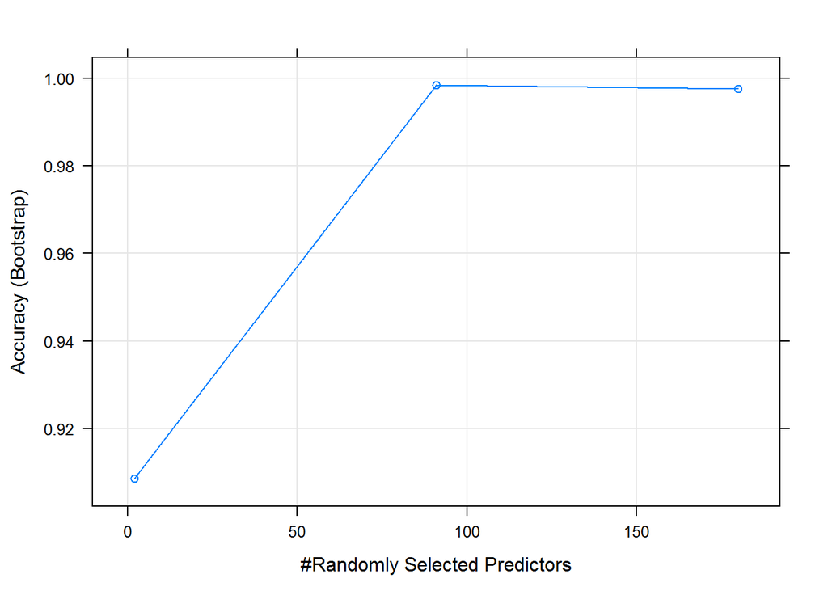

```r
plot(rfMod)
```

```r
updated <-training
updated<-updated[,-grep("kurtosis",colnames(updated))]
updated<-updated[,-grep("max",colnames(updated))]
updated<-updated[,-grep("min",colnames(updated))]
updated<-updated[,-grep("skewness",colnames(updated))]
updated<-updated[,-grep("var",colnames(updated))]
updated<-updated[,-grep("gyros",colnames(updated))]
```

```r
ctrl <-trainControl(method="cv", number=5)
newModel <- train(classe ~.,data=updated, method="rf", ntree=200,trainControl=ctrl, returnData=FALSE, returnResamp="none", savePredictions=FALSE )
```

```r
newModel
```

```
## Random Forest
##
## 13737 samples
##    82 predictor
##     5 classes: 'A', 'B', 'C', 'D', 'E'
##
## No pre-processing
## Resampling: Bootstrapped (25 reps)
## Summary of sample sizes: 13737, 13737, 13737, 13737, 13737, 13737, ...
## Resampling results across tuning parameters:
##
##   mtry  Accuracy   Kappa      Accuracy SD   Kappa SD
##     2   0.9519719  0.9391737  0.0034973620  0.0043864336
##    53   0.9982965  0.9978457  0.0005752112  0.0007261578
##   104   0.9978292  0.9972543  0.0008844416  0.0011172061
##
## Accuracy was used to select the optimal model using  the largest value.
## The final value used for the model was mtry = 53.
```

```r
newModel$finalModel
```

```
##
## Call:
##  randomForest(x = x, y = y, ntree = 200, mtry = param$mtry, trainControl = ..2,      returnData = FALSE, returnResamp = "none", savePredictions = FALSE)
##                Type of random forest: classification
##                      Number of trees: 200
## No. of variables tried at each split: 53
##
##         OOB estimate of  error rate: 0.09%
## Confusion matrix:
##      A    B    C    D    E  class.error
## A 3906    0    0    0    0 0.0000000000
## B    4 2653    1    0    0 0.0018811136
## C    0    1 2394    1    0 0.0008347245
## D    0    0    3 2248    1 0.0017761989
## E    0    0    0    2 2523 0.0007920792
```

Finally a Cross Validation prediction is generated with the updated model using the smaller parameter set:

```r
newPred <- predict(newModel,testing)
table(newPred,testing$classe)
```

```
##
## newPred    A    B    C    D    E
##       A 1674    0    0    0    0
##       B    0 1139    1    0    0
##       C    0    0 1025    0    0
##       D    0    0    0  964    0
##       E    0    0    0    0 1082
```

### References

[1] Human Activity Recognition Data Set - http://groupware.les.inf.puc-rio.br/har [2] Performance Modeling tips - https://class.coursera.org/predmachlearn-031/forum/thread?thread_id=12